# Client Report - Project 5

- Show All Code
- Hide All Code

Course DS 250

Author

Luis Fernando Mendoza

## Elevator pitch

Use the force to predict the current income of your job’s candidates! Stop being in the dark side! Come and see how this study can help you indentify top talent, true jedys for you company. Our predictive model allows you to streamline your recruitment efforts and make more informed hiring decisions. Join us on a journey to bring the power of data science to the galaxy of recruitment.

**Read and format project data**

```python
# Include and execute your code here
df = pd.read_csv("https://raw.githubusercontent.com/fivethirtyeight/data/master/star-wars-survey/StarWars.csv", encoding="ISO-8859-1")
```

**Highlight the Questions and Tasks**

## Question|Task 1

Shorten the column names and clean them up for easier use with pandas. Provide a table or list that exemplifies how you fixed the names.

Here you can see an example of the result of the surveys where we asked people about which star wards movies they have seen and their salaries.

```python
# Define the new column names
new_column_names = [
    "respondent_id",
    "seen_star_wars",
    "star_wars_fan",
    "seen_sw_ep1", "seen_sw_ep2", "seen_sw_ep3", "seen_sw_ep4", "seen_sw_ep5", "seen_sw_ep6",
    "ranking_sw_ep1", "ranking_sw_ep2", "ranking_sw_ep3", "ranking_sw_ep4", "ranking_sw_ep5", "ranking_sw_ep6",
    "fav_character_han", "fav_character_luke", "fav_character_leia", "fav_character_anakin",
    "fav_character_obi_wan", "fav_character_emperor", "fav_character_darth_vader", "fav_character_lando",
    "fav_character_boba_fett", "fav_character_c_3p0", "fav_character_r2_d2", "fav_character_jar_jar",
    "fav_character_padme", "fav_character_yoda",
    "shot_first",
    "expanded_universe",
    "eu_fan",
    "star_trek_fan",
    "gender",
    "age_midpoint",
    "income",
    "education",
    "location"
]

# Assign new column names to the DataFrame
df.columns = new_column_names

# Display the modified DataFrame
df.head(10)
```

|  | respondent_id | seen_star_wars | star_wars_fan | seen_sw_ep1 | seen_sw_ep2 | seen_sw_ep3 | seen_sw_ep4 | seen_sw_ep5 | seen_sw_ep6 | ranking_sw_ep1 | ... | fav_character_yoda | shot_first | expanded_universe | eu_fan | star_trek_fan | gender | age_midpoint | income | education | location |
| --- | --- | --- | --- | --- | --- | --- | --- | --- | --- | --- | --- | --- | --- | --- | --- | --- | --- | --- | --- | --- | --- |
| 0 | NaN | Response | Response | Star Wars: Episode I The Phantom Menace | Star Wars: Episode II Attack of the Clones | Star Wars: Episode III Revenge of the Sith | Star Wars: Episode IV A New Hope | Star Wars: Episode V The Empire Strikes Back | Star Wars: Episode VI Return of the Jedi | Star Wars: Episode I The Phantom Menace | ... | Yoda | Response | Response | Response | Response | Response | Response | Response | Response | Response |
| 1 | 3.292880e+09 | Yes | Yes | Star Wars: Episode I The Phantom Menace | Star Wars: Episode II Attack of the Clones | Star Wars: Episode III Revenge of the Sith | Star Wars: Episode IV A New Hope | Star Wars: Episode V The Empire Strikes Back | Star Wars: Episode VI Return of the Jedi | 3 | ... | Very favorably | I don't understand this question | Yes | No | No | Male | 18-29 | NaN | High school degree | South Atlantic |
| 2 | 3.292880e+09 | No | NaN | NaN | NaN | NaN | NaN | NaN | NaN | NaN | ... | NaN | NaN | NaN | NaN | Yes | Male | 18-29 | $0 - $24,999 | Bachelor degree | West South Central |
| 3 | 3.292765e+09 | Yes | No | Star Wars: Episode I The Phantom Menace | Star Wars: Episode II Attack of the Clones | Star Wars: Episode III Revenge of the Sith | NaN | NaN | NaN | 1 | ... | Unfamiliar (N/A) | I don't understand this question | No | NaN | No | Male | 18-29 | $0 - $24,999 | High school degree | West North Central |
| 4 | 3.292763e+09 | Yes | Yes | Star Wars: Episode I The Phantom Menace | Star Wars: Episode II Attack of the Clones | Star Wars: Episode III Revenge of the Sith | Star Wars: Episode IV A New Hope | Star Wars: Episode V The Empire Strikes Back | Star Wars: Episode VI Return of the Jedi | 5 | ... | Very favorably | I don't understand this question | No | NaN | Yes | Male | 18-29 | $100,000 - $149,999 | Some college or Associate degree | West North Central |
| 5 | 3.292731e+09 | Yes | Yes | Star Wars: Episode I The Phantom Menace | Star Wars: Episode II Attack of the Clones | Star Wars: Episode III Revenge of the Sith | Star Wars: Episode IV A New Hope | Star Wars: Episode V The Empire Strikes Back | Star Wars: Episode VI Return of the Jedi | 5 | ... | Somewhat favorably | Greedo | Yes | No | No | Male | 18-29 | $100,000 - $149,999 | Some college or Associate degree | West North Central |
| 6 | 3.292719e+09 | Yes | Yes | Star Wars: Episode I The Phantom Menace | Star Wars: Episode II Attack of the Clones | Star Wars: Episode III Revenge of the Sith | Star Wars: Episode IV A New Hope | Star Wars: Episode V The Empire Strikes Back | Star Wars: Episode VI Return of the Jedi | 1 | ... | Very favorably | Han | Yes | No | Yes | Male | 18-29 | $25,000 - $49,999 | Bachelor degree | Middle Atlantic |
| 7 | 3.292685e+09 | Yes | Yes | Star Wars: Episode I The Phantom Menace | Star Wars: Episode II Attack of the Clones | Star Wars: Episode III Revenge of the Sith | Star Wars: Episode IV A New Hope | Star Wars: Episode V The Empire Strikes Back | Star Wars: Episode VI Return of the Jedi | 6 | ... | Very favorably | Han | Yes | No | No | Male | 18-29 | NaN | High school degree | East North Central |
| 8 | 3.292664e+09 | Yes | Yes | Star Wars: Episode I The Phantom Menace | Star Wars: Episode II Attack of the Clones | Star Wars: Episode III Revenge of the Sith | Star Wars: Episode IV A New Hope | Star Wars: Episode V The Empire Strikes Back | Star Wars: Episode VI Return of the Jedi | 4 | ... | Very favorably | Han | No | NaN | Yes | Male | 18-29 | NaN | High school degree | South Atlantic |
| 9 | 3.292654e+09 | Yes | Yes | Star Wars: Episode I The Phantom Menace | Star Wars: Episode II Attack of the Clones | Star Wars: Episode III Revenge of the Sith | Star Wars: Episode IV A New Hope | Star Wars: Episode V The Empire Strikes Back | Star Wars: Episode VI Return of the Jedi | 5 | ... | Somewhat favorably | Han | No | NaN | No | Male | 18-29 | $0 - $24,999 | Some college or Associate degree | South Atlantic |

10 rows × 38 columns

**Highlight the Questions and Tasks**

## Question|Task 2

Clean and format the data so that it can be used in a machine learning model. As you format the data, you should complete each item listed below. In your final report provide example(s) of the reformatted data with a short description of the changes made.

a-Filter the dataset to respondents that have seen at least one film.

```python
# Filter the dataset to respondents that have seen at least one film
df_filtered = df[df["seen_star_wars"] == "Yes"].copy()
```

b- Create a new column that converts the age ranges to a single number. Drop the age range categorical column.

```python
# Convert age ranges to a single number
age_mapping = {
    "18-29": 24,
    "30-44": 37,
    "45-60": 52.5,
    "> 60": 70
}
df_filtered["age_midpoint"] = df_filtered["age_midpoint"].map(age_mapping)

# Drop the original age range column
df_filtered.drop("age_midpoint", axis=1, inplace=True)
```

c- Create a new column that converts the education groupings to a single number. Drop the school categorical column

```python
# Convert education groupings to a single number
education_mapping = {
    "High school degree": 1,
    "Some college or Associate degree": 2,
    "Bachelor degree": 3,
    "Graduate degree": 4
}
df_filtered["education_level"] = df_filtered["education"].map(education_mapping)
# Drop the original education column
df_filtered.drop("education", axis=1, inplace=True)
```

d- Create a new column that converts the income ranges to a single number. Drop the income range categorical column.

```python
# Convert income ranges to a single number
income_mapping = {
    "$0 - $24,999": 12500,
    "$25,000 - $49,999": 37500,
    "$50,000 - $99,999": 75000,
    "$100,000 - $149,999": 125000,
    "$150,000+": 175000
}
df_filtered["income_midpoint"] = df_filtered["income"].map(income_mapping)
# Drop the original income range column
df_filtered.drop("income", axis=1, inplace=True)
```

e- Create your target (also known as “y” or “label”) column based on the new income range column.

```python
# Create the target column
df_filtered["target"] = (df_filtered["income_midpoint"] >= 50000).astype(int)
```

f- One-hot encode all remaining categorical columns.

```python
# One-hot encode remaining categorical columns
df_encoded = pd.get_dummies(df_filtered, columns=["gender", "location", "star_trek_fan", "expanded_universe"])
```

**Highlight the Questions and Tasks**

## Question|Task 3

Validate that the data provided on GitHub lines up with the article by recreating 2 of the visuals from the article.

```python
# Define a dictionary mapping column names to movie titles
movie_titles = {
    "seen_sw_ep1": "The Phantom Menace",
    "seen_sw_ep2": "Attack of the Clones",
    "seen_sw_ep3": "Revenge of the Sith",
    "seen_sw_ep4": "A New Hope",
    "seen_sw_ep5": "The Empire Strikes Back",
    "seen_sw_ep6": "Return of the Jedi"
}

# Convert movie seen columns to binary values
for col in df_filtered.columns[3:9]:
    df_filtered[col] = df_filtered[col].notnull().astype(int)

# Now, you can calculate the sum of each column
seen_counts = df_filtered.iloc[:, 3:9].sum()

# Calculate the total number of respondents
total_respondents = len(df_filtered)

# Convert counts to percentages
seen_percentages = (seen_counts / total_respondents) * 100

# Replace column names with movie titles
seen_percentages.index = [movie_titles[col] for col in seen_percentages.index]

# Create a bar plot
fig1 = px.bar(x=seen_percentages.values, y=seen_percentages.index,
              labels={'x': 'Percentage of Respondents (%)', 'y': 'Star Wars Movies'},
              title='Which Star Wars Movies Have You Seen?', orientation='h')
fig1.show()
```

[interactive chart not shown]

```python
# Convert the columns containing movie rankings to numeric
df_filtered.iloc[:, 9:15] = df_filtered.iloc[:, 9:15].astype(float)

# Calculate the average rankings of Star Wars movies
avg_rankings = df_filtered.iloc[:, 9:15].mean()

# Define a dictionary mapping column names to movie titles
movie_titles = {
    "ranking_sw_ep1": "The Phantom Menace",
    "ranking_sw_ep2": "Attack of the Clones",
    "ranking_sw_ep3": "Revenge of the Sith",
    "ranking_sw_ep4": "A New Hope",
    "ranking_sw_ep5": "The Empire Strikes Back",
    "ranking_sw_ep6": "Return of the Jedi"
}

# Create a bar plot with movie titles
fig2 = px.bar(y=avg_rankings.values, x=[movie_titles[col] for col in avg_rankings.index],
              labels={'y': 'Average Ranking', 'x': 'Star Wars Movies'},
              title='What is the best Star Wars Movie?', orientation='h')
fig2.show()
```

[interactive chart not shown]

**Highlight the Questions and Tasks**

## Question|Task 4

Build a machine learning model that predicts whether a person makes more than $50k. Describe your model and report the accuracy.

```python
# One-hot encode categorical columns
df_encoded = pd.get_dummies(df_filtered, columns=["gender", "location", "star_trek_fan", "expanded_universe"])

# Define features (X) and target variable (y)
X = df_encoded.drop("target", axis=1)
y = df_encoded["target"]

# Split the data into training and testing sets
X_train, X_test, y_train, y_test = train_test_split(X, y, test_size=0.2, random_state=42)

# Get list of categorical columns
categorical_cols = X.select_dtypes(include=['object']).columns.tolist()

# Initialize the imputer with mean strategy, excluding categorical columns
imputer = SimpleImputer(strategy='mean')
X_train_numeric = X_train.drop(columns=categorical_cols)
X_test_numeric = X_test.drop(columns=categorical_cols)

# Fit the imputer on the training data and transform the training data
X_train_imputed = imputer.fit_transform(X_train_numeric)

# Transform the testing data using the fitted imputer
X_test_imputed = imputer.transform(X_test_numeric)
```

```python
# Initialize and train the Random Forest Classifier
rf_classifier = RandomForestClassifier(random_state=42)
rf_classifier.fit(X_train_imputed, y_train)

# Predict the target variable on the testing set
y_pred = rf_classifier.predict(X_test_imputed)

# Predict the target variable on the testing set
y_pred = rf_classifier.predict(X_test_imputed)

# Calculate accuracy
accuracy = accuracy_score(y_test, y_pred)
print("Accuracy:", accuracy)

# Calculate precision
precision = precision_score(y_test, y_pred)
print("Precision:", precision)

# Calculate recall
recall = recall_score(y_test, y_pred)
print("Recall:", recall)

# Calculate F1-score
f1 = f1_score(y_test, y_pred)
print("F1-score:", f1)
```

```
Accuracy: 0.9627659574468085
Precision: 0.9468085106382979
Recall: 0.978021978021978
F1-score: 0.9621621621621622
```

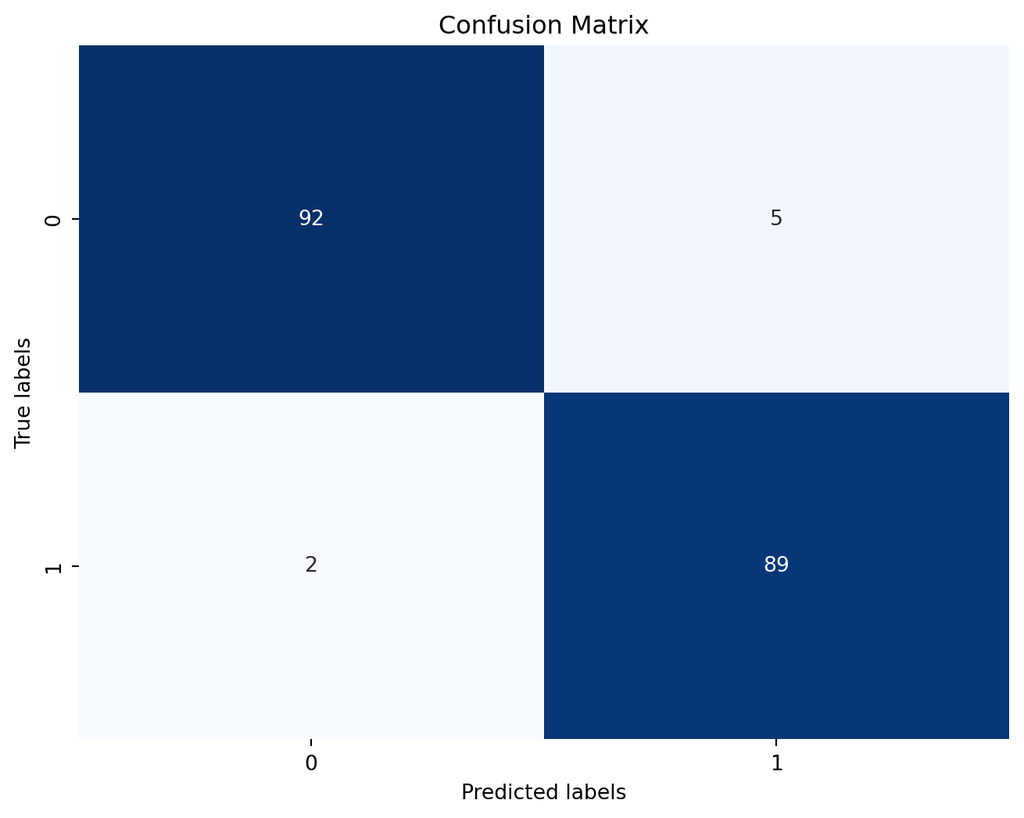

```python
# Calculate confusion matrix
conf_matrix = confusion_matrix(y_test, y_pred)

# Plot confusion matrix
plt.figure(figsize=(8, 6))
sns.heatmap(conf_matrix, annot=True, fmt='d', cmap='Blues', cbar=False)
plt.xlabel('Predicted labels')
plt.ylabel('True labels')
plt.title('Confusion Matrix')
plt.show()
```

```python
# Define hyperparameters grid
param_grid = {
    'n_estimators': [50, 100, 150],
    'max_depth': [None, 10, 20],
    'min_samples_split': [2, 5, 10],
    'min_samples_leaf': [1, 2, 4]
}

# Initialize Random Forest Classifier
rf_classifier_tuned = RandomForestClassifier(random_state=42)

# Perform Grid Search Cross Validation
grid_search = GridSearchCV(rf_classifier_tuned, param_grid, cv=5, scoring='accuracy')
grid_search.fit(X_train_imputed, y_train)

# Print best parameters
print("Best Parameters:", grid_search.best_params_)

# Get best estimator
best_rf_classifier = grid_search.best_estimator_

# Predict the target variable on the testing set with the best estimator
y_pred_tuned = best_rf_classifier.predict(X_test_imputed)
```

```
Best Parameters: {'max_depth': None, 'min_samples_leaf': 1, 'min_samples_split': 5, 'n_estimators': 150}
```